# Machine Learning: Exercise Class Classification

## Summary

In the report below, I fit a series of models to an exercise data set using three Machine Learning algorithms. The models’ purpose is to classify the manner in which the exercise was done (A, B, C, D, or E) for each observation. Using cross-validation, I estimate the out-of-sample error rate of each algorithm. Finally, I select the algorithm with the lowest estimated out-of-sample error rate, and select, as the final model, that model generated using the selected algorithm and fit using the complete training data set.

## Load Libraries

The “caret” library must be loaded in order to utilize the machine learning algorithms required below.

## Data Import

Data is imported from the file “pml-training.csv”, which were downloaded from https://d396qusza40orc.cloudfront.net/predmachlearn/pml-training.csv.

```r
training = read.csv("pml-training.csv",na.strings=c(""," ","NA","#DIV/0!"))
```

## Data Cleaning and Setup

First, the training data set was cleaned up. Features (columns) that should not contribute to the model (such as user name and time stamp) were removed, and features that have a value of “na” for most observations were also removed.

```r
training <- training[,8:160]
toomanyna <- lapply(training,function(x) sum(is.na(x))) > 15000
training <- training[,-which(toomanyna)]
```

No “na” values remained in the cleaned data set, so no further cleaning or imputing was carried out.

```r
any(is.na(training))
```

```
## [1] FALSE
```

The random number generator seed was set.

```r
set.seed(8182020)
```

## Model Fitting

### Linear Discriminant Analysis

```r
tc <- trainControl(method="cv",number=4,verboseIter=FALSE,returnResamp="all",savePredictions="all",preProcOptions=c("center","scale"))
mfLDA <- train(classe~.,data=training,trControl=tc,preProcess=c("center","scale"),method="lda")
mfLDA
```

```
## Linear Discriminant Analysis
##
## 19622 samples
##    52 predictor
##     5 classes: 'A', 'B', 'C', 'D', 'E'
##
## Pre-processing: centered (52), scaled (52)
## Resampling: Cross-Validated (4 fold)
## Summary of sample sizes: 14715, 14718, 14717, 14716
## Resampling results:
##
##   Accuracy   Kappa
##   0.7009977  0.6216082
```

### Classification and Regressions Trees

```r
mfRPART <- train(classe~.,data=training,trControl=tc,preProcess=c("center","scale"),method="rpart")
mfRPART
```

```
## CART
##
## 19622 samples
##    52 predictor
##     5 classes: 'A', 'B', 'C', 'D', 'E'
##
## Pre-processing: centered (52), scaled (52)
## Resampling: Cross-Validated (4 fold)
## Summary of sample sizes: 14718, 14715, 14716, 14717
## Resampling results across tuning parameters:
##
##   cp          Accuracy   Kappa
##   0.03567868  0.5044848  0.35209516
##   0.05998671  0.4293646  0.23104161
##   0.11515454  0.3243767  0.06090376
##
## Accuracy was used to select the optimal model using the largest value.
## The final value used for the model was cp = 0.03567868.
```

### Random Forest

Random forest (RF) models were also fit to the training set. The RF models were much slower to train than the LDA and RPART models, and given the size of the training set (19622 observations), 10-fold cross-validation was too time-consuming to use in this case. Instead, “leave one group out cross-validation” (LGOCV) was used. This method is also known as “Monte Carlo cross-validation. The training control parameters were set such that 10 random samples (number=10), each containing 20% of the training set observations (p=0.2) were taken as”folds" for subsequent RF model training. On average, each observation is thus included in the training set for two of the RF models. Once again, the data sets were centered and scaled.

```r
tc <- trainControl(method="LGOCV",number=10,p=0.2,verboseIter=FALSE,returnResamp="all",savePredictions="all",preProcOptions=c("center","scale"))
mfRF <- train(classe~.,data=training[,1:53],trControl=tc,preProcess=c("center","scale"),method="rf")
mfRF
```

```
## Random Forest
##
## 19622 samples
##    52 predictor
##     5 classes: 'A', 'B', 'C', 'D', 'E'
##
## Pre-processing: centered (52), scaled (52)
## Resampling: Repeated Train/Test Splits Estimated (10 reps, 20%)
## Summary of sample sizes: 3927, 3927, 3927, 3927, 3927, 3927, ...
## Resampling results across tuning parameters:
##
##   mtry  Accuracy   Kappa
##    2    0.9688754  0.9606090
##   27    0.9721886  0.9648082
##   52    0.9626442  0.9527312
##
## Accuracy was used to select the optimal model using the largest value.
## The final value used for the model was mtry = 27.
```

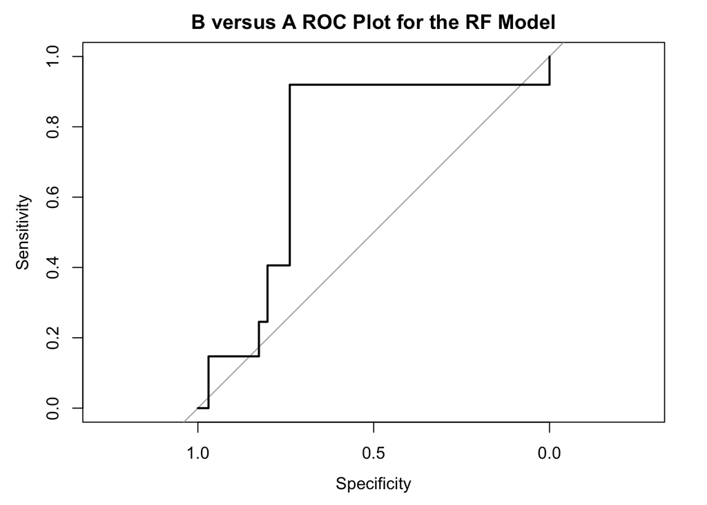

```r
RFROC <- roc(training$classe,as.numeric(predict(mfRF,training)),levels=c("A","B"))
plot(RFROC,type="S",main="B versus A ROC Plot for the RF Model")
```

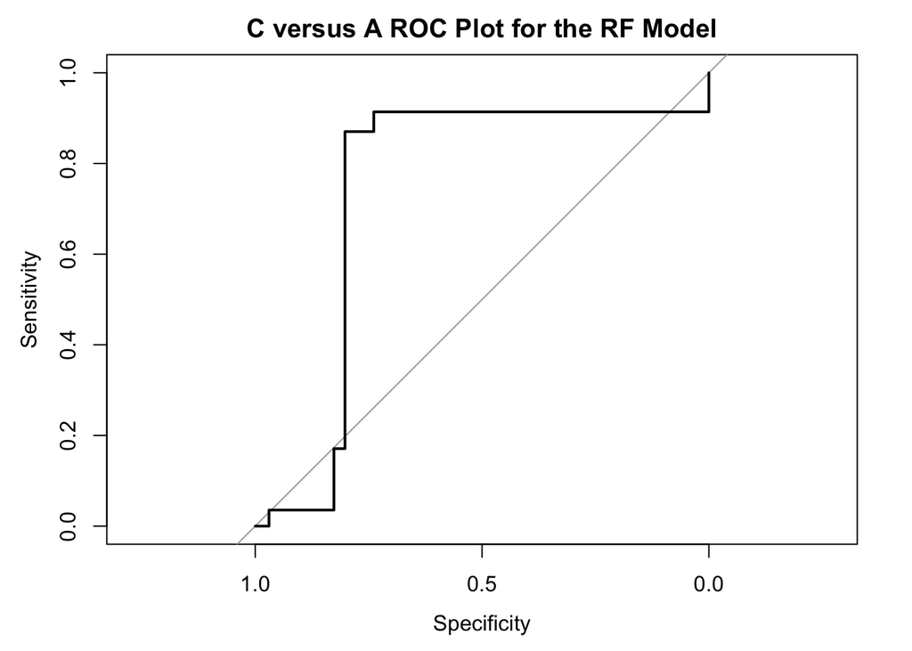

```r
RFROC <- roc(training$classe,as.numeric(predict(mfRF,training)),levels=c("A","C"))
plot(RFROC,type="S",main="C versus A ROC Plot for the RF Model")
```

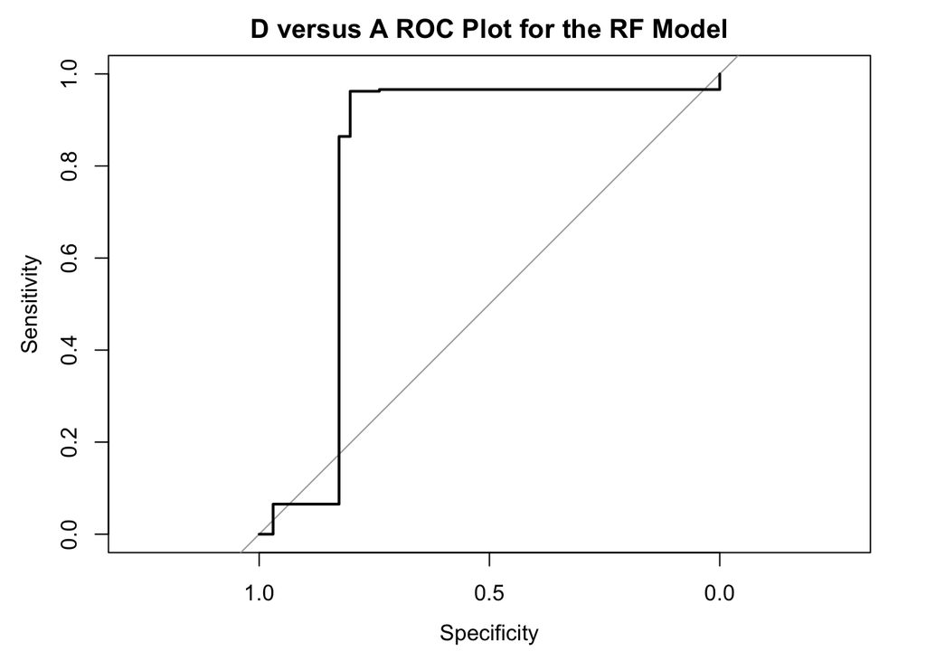

```r
RFROC <- roc(training$classe,as.numeric(predict(mfRF,training)),levels=c("A","D"))
plot(RFROC,type="S",main="D versus A ROC Plot for the RF Model")
```

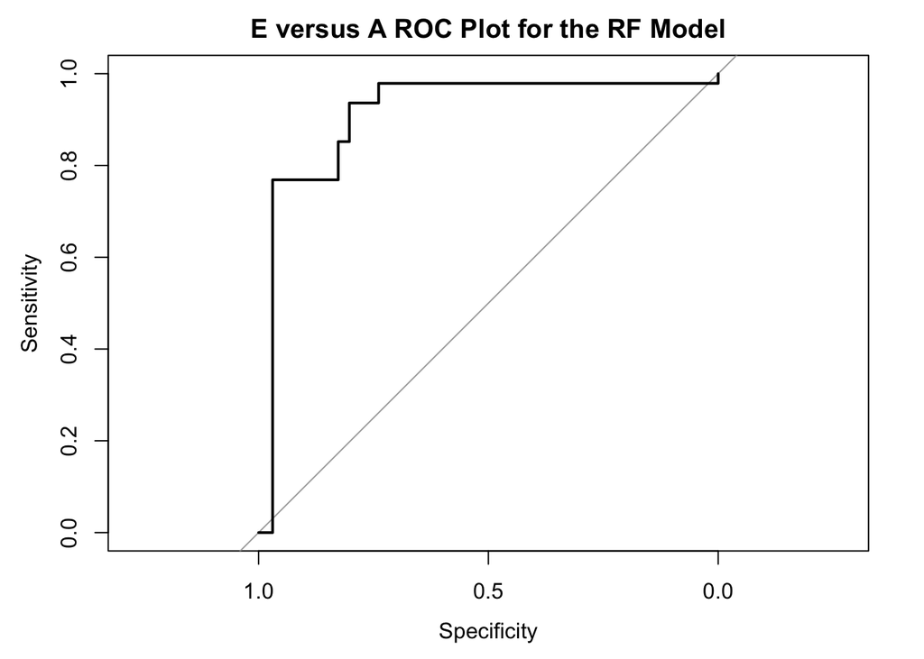

```r
RFROC <- roc(training$classe,as.numeric(predict(mfRF,training)),levels=c("A","E"))
plot(RFROC,type="S",main="E versus A ROC Plot for the RF Model")
```